# Clasificación con Naive Bayes

# 1. Introducción

- Vimos que el algoritmo Naive Bayes clasifica de manera probabilística.
- La probabilidad de que un objeto pertenezca a cierta clase depende de las características que tenga.
- Esto, por medio del cálculo de probabilidades posteriores en función de los datos de entrenamiento.
- Para filtrar correos spam, por ejemplo, las palabras contenidas en el correo determinan la clase a la que pertenece.
- Esto en función de la frecuencia de dichas palabras en correos previamente clasificados como spam o no.
- Aplicaremos esta técnica para asignar legisladores a un partido en función de su comportamiento legislativo.

# 2. Predicción del partido político de legisladores en EE.UU.

- Usaremos el algoritmo Naive Bayes para predecir el partido político de los legisladores.
- Tenemos información sobre representantes a la Cámara en EE.UU.
- La base `votos84.csv` contiene información sobre un conjunto de representantes a la Cámara en EE.UU. en 1984.
- También contiene información sobre cómo votaron (Sí o No) en un conjunto de 16 proposiciones durante su legislatura.
- La idea es mostrar cómo el comportamiento legislativo permite determinar la ideología y, por ende, el partido de estos congresistas.

# 3. Datos

- Leamos los datos como un *data frame*.
- Como todas las variables son categóricas (el partido y los 16 votos), las leemos como factores con `stringsAsFactors = TRUE`. Esto es necesario para que Naive Bayes las trate correctamente:

```r
votos84 <- read.csv("data/votos84.csv", stringsAsFactors = TRUE)
```

- Veamos la estructura de los datos:

```r
str(votos84)
```

```
## 'data.frame':    435 obs. of  17 variables:
##  $ Class: Factor w/ 2 levels "democrat","republican": 2 2 1 1 1 1 1 2 2 1 ...
##  $ V1   : Factor w/ 2 levels "n","y": 1 1 2 1 2 1 1 1 1 2 ...
##  $ V2   : Factor w/ 2 levels "n","y": 2 2 2 2 2 2 2 2 2 2 ...
##  $ V3   : Factor w/ 2 levels "n","y": 1 1 2 2 2 2 1 1 1 2 ...
##  $ V4   : Factor w/ 2 levels "n","y": 2 2 2 1 1 1 2 2 2 1 ...
##  $ V5   : Factor w/ 2 levels "n","y": 2 2 2 1 2 2 2 2 2 1 ...
##  $ V6   : Factor w/ 2 levels "n","y": 2 2 2 2 2 2 2 2 2 1 ...
##  $ V7   : Factor w/ 2 levels "n","y": 1 1 1 1 1 1 1 1 1 2 ...
##  $ V8   : Factor w/ 2 levels "n","y": 1 1 1 1 1 1 1 1 1 2 ...
##  $ V9   : Factor w/ 2 levels "n","y": 1 1 1 1 1 1 1 1 1 2 ...
##  $ V10  : Factor w/ 2 levels "n","y": 2 1 1 1 1 1 1 1 1 1 ...
##  $ V11  : Factor w/ 2 levels "n","y": 1 1 2 2 2 1 1 1 1 1 ...
##  $ V12  : Factor w/ 2 levels "n","y": 2 2 1 1 1 1 1 1 2 1 ...
##  $ V13  : Factor w/ 2 levels "n","y": 2 2 2 2 2 2 1 2 2 1 ...
##  $ V14  : Factor w/ 2 levels "n","y": 2 2 2 1 2 2 2 2 2 1 ...
##  $ V15  : Factor w/ 2 levels "n","y": 1 1 1 1 2 2 2 2 1 2 ...
##  $ V16  : Factor w/ 2 levels "n","y": 2 1 1 2 2 2 2 2 2 1 ...
```

- Grafiquemos la proporción de votos por el asunto 1 (`V1`) para el total de legisladores:

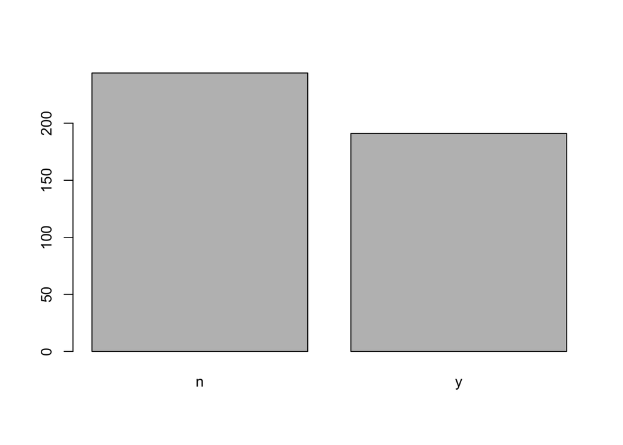

```r
plot(votos84$V1)
```

- Ahora lo mismo, pero solo para los legisladores republicanos:

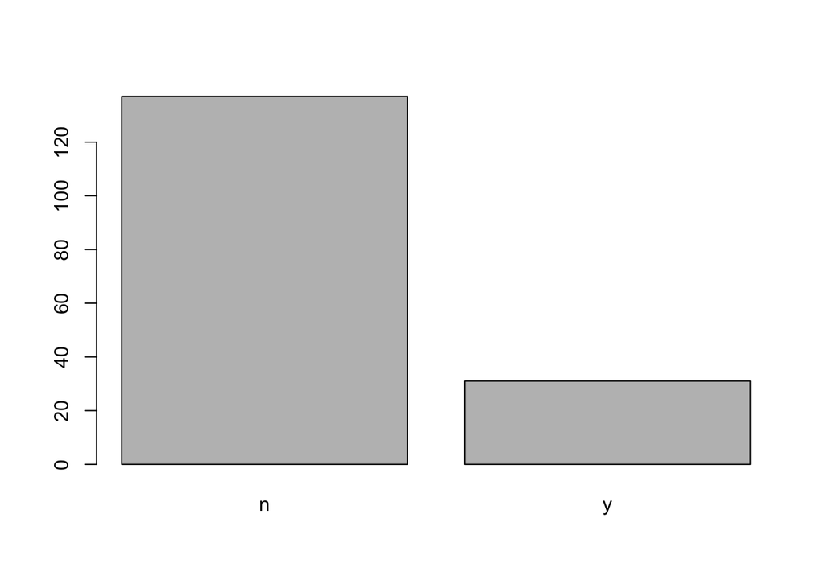

```r
plot(votos84[votos84$Class == "republican", "V1"])
```

- Y ahora para los demócratas:

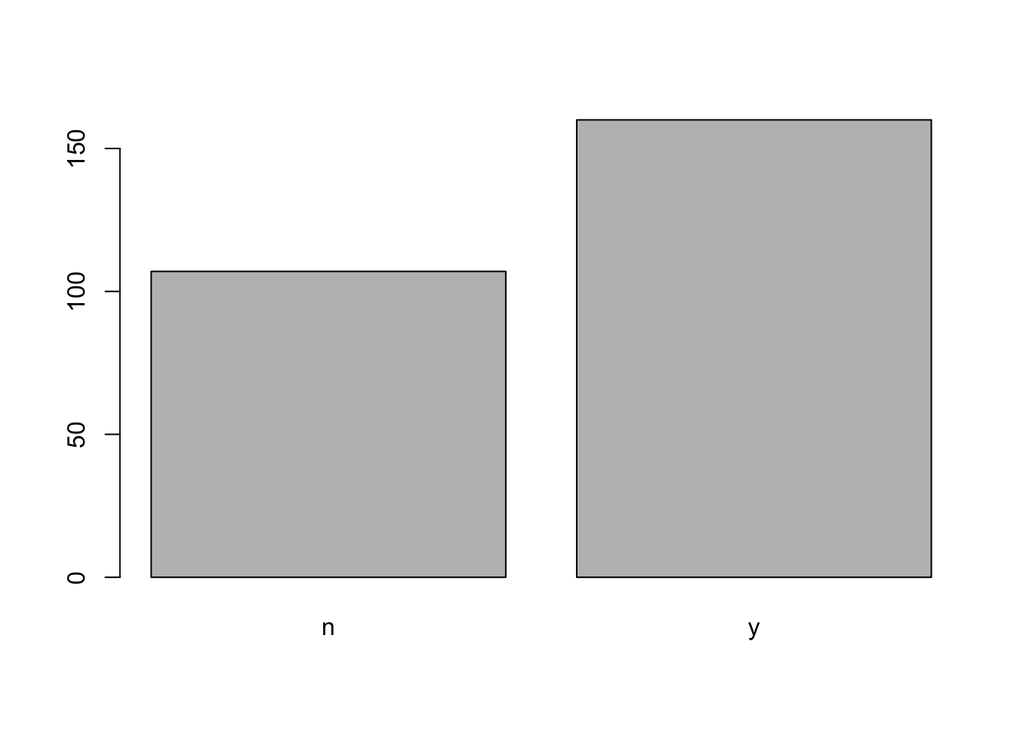

```r
plot(votos84[votos84$Class == "democrat", "V1"])
```

- Claramente se ven diferencias en el comportamiento legislativo entre los miembros de un partido y del otro.
- Estas son las diferencias que explotaremos.

# 4. Preparación de los datos

- Dividiremos la base en dos: 335 observaciones para entrenar el modelo y las 100 restantes para probarlo.
- Hacemos esta división de manera aleatoria.
- Para esto creamos un vector de 335 números que pueden tomar cualquier valor entre 1 y 435.
- Esos números serán las observaciones que formarán parte del conjunto de entrenamiento; el resto serán las del conjunto de prueba.
- Fijemos primero una semilla para poder replicar los resultados después.
- Este paso es importante siempre que haya un procedimiento aleatorio de por medio que queramos replicar:

```r
set.seed(123)
```

- Creemos un vector de 335 números aleatorios entre 1 y 435:

```r
train_sample <- sample(435, 335)
```

- Echémosle un vistazo al vector:

```r
str(train_sample)
```

```
##  int [1:335] 415 179 14 195 426 306 118 299 229 244 ...
```

- Cada número es una fila que integrará el conjunto de entrenamiento.
- Creemos las bases de entrenamiento y prueba usando el vector aleatorio que acabamos de crear:

```r
votos84_train <- votos84[train_sample, ]
votos84_test <- votos84[-train_sample, ]
```

- Creemos los vectores con los *outcomes* (la clase de cada legislador):

```r
votos84_train_labels <- votos84_train$Class
votos84_test_labels <- votos84_test$Class
```

- Eliminemos la columna del *outcome* (`Class`) en las bases de entrenamiento y prueba, para dejar solo las características:

```r
votos84_train <- votos84_train[, -1]
votos84_test <- votos84_test[, -1]
```

- Inspeccionemos las bases resultantes:

```r
str(votos84_train)
```

```
## 'data.frame':    335 obs. of  16 variables:
##  $ V1 : Factor w/ 2 levels "n","y": 2 2 2 1 1 1 2 1 1 1 ...
##  $ V2 : Factor w/ 2 levels "n","y": 2 1 2 1 1 1 2 2 2 2 ...
##  $ V3 : Factor w/ 2 levels "n","y": 2 2 2 2 2 1 2 1 1 2 ...
##  $ V4 : Factor w/ 2 levels "n","y": 1 1 1 1 1 2 2 1 2 1 ...
##  $ V5 : Factor w/ 2 levels "n","y": 1 1 1 1 1 2 2 1 2 1 ...
##  $ V6 : Factor w/ 2 levels "n","y": 1 1 2 2 1 2 1 1 2 1 ...
##  $ V7 : Factor w/ 2 levels "n","y": 2 2 2 2 2 1 2 2 1 2 ...
##  $ V8 : Factor w/ 2 levels "n","y": 2 2 2 2 2 1 1 2 1 2 ...
##  $ V9 : Factor w/ 2 levels "n","y": 2 2 2 2 1 1 1 2 1 2 ...
##  $ V10: Factor w/ 2 levels "n","y": 1 2 2 2 2 2 1 2 1 2 ...
##  $ V11: Factor w/ 2 levels "n","y": 1 2 2 2 2 1 1 2 1 1 ...
##  $ V12: Factor w/ 2 levels "n","y": 1 1 1 1 1 2 2 1 2 1 ...
##  $ V13: Factor w/ 2 levels "n","y": 1 1 1 1 1 2 2 1 2 2 ...
##  $ V14: Factor w/ 2 levels "n","y": 1 1 1 1 1 2 2 1 2 1 ...
##  $ V15: Factor w/ 2 levels "n","y": 1 2 2 2 2 1 1 2 1 2 ...
##  $ V16: Factor w/ 2 levels "n","y": 2 2 2 2 2 1 2 2 2 2 ...
```

# 5. Entrenamiento del modelo

- Ahora sí estamos listos para utilizar el algoritmo.
- Con base en el comportamiento legislativo, se estimará la probabilidad de que un congresista sea republicano o demócrata.
- Para esto usaremos el paquete `e1071`, que incluye una variedad de funciones de machine learning, entre ellas una para hacer Naive Bayes.
- Si no lo tienes instalado, descoméntalo y ejecútalo una sola vez:

```r
install.packages("e1071")
```

```r
library(e1071)
```

- En este paquete los procesos de entrenamiento y predicción se hacen en etapas separadas.
- Para entrenar usamos la función `naiveBayes()`, con la sintaxis: `m <- naiveBayes(train, class, laplace)`, donde:
  - `m` es el nombre que le damos al objeto.
  - `train` es el *data frame* o matriz con los datos de entrenamiento.
  - `class` es un vector tipo factor que indica la clase de cada fila de entrenamiento.
  - `laplace` es el parámetro que controla el estimador de Laplace (por defecto, `laplace = 0`).
- El objeto que devuelve esta función nos sirve para hacer las predicciones.
- Estimemos el modelo con nuestros datos de entrenamiento:

```r
votos84_classifier <- naiveBayes(votos84_train, votos84_train_labels)
```

# 6. Predicciones y desempeño del modelo

- Predecimos con la función `predict()`, que tiene la sintaxis: `p <- predict(m, test, type)`, donde:
  - `m` es el objeto estimado con `naiveBayes()`.
  - `test` es el *data frame* o matriz con los datos de prueba.
  - `type` puede ser `"class"` (devuelve la categoría predicha) o `"raw"` (devuelve la probabilidad). Por defecto es `"class"`.
- La predicción sobre la base de prueba en nuestro ejemplo es:

```r
votos84_test_pred <- predict(votos84_classifier, votos84_test)
```

- Veamos cómo nos fue, con la función `CrossTable()` del paquete `gmodels`. Carguemos el paquete:

```r
install.packages("gmodels")
```

```r
library(gmodels)
```

- Creemos la tabla que compara las predicciones con la clase real:

```r
CrossTable(votos84_test_pred, votos84_test_labels, prop.chisq = FALSE,
           prop.r = FALSE, prop.c = FALSE, dnn = c("predicho", "real"))
```

```
##
##
##    Cell Contents
## |-------------------------|
## |                       N |
## |         N / Table Total |
## |-------------------------|
##
##
## Total Observations in Table:  100
##
##
##              | real
##     predicho |   democrat | republican |  Row Total |
## -------------|------------|------------|------------|
##     democrat |         53 |          0 |         53 |
##              |      0.530 |      0.000 |            |
## -------------|------------|------------|------------|
##   republican |          6 |         41 |         47 |
##              |      0.060 |      0.410 |            |
## -------------|------------|------------|------------|
## Column Total |         59 |         41 |        100 |
## -------------|------------|------------|------------|
##
##
```

- En la diagonal de la tabla están los aciertos: legisladores cuyo partido fue correctamente predicho a partir de sus votos.
- Fuera de la diagonal están los errores de clasificación.
- El modelo logra clasificar correctamente a la gran mayoría de los legisladores, lo que confirma que el comportamiento legislativo es muy informativo sobre la afiliación partidista.
- Como ejercicio, prueba a reestimar el modelo con `laplace = 1` y compara los resultados.